# FordGoBike Analysis

## by Justin Brown

## Investigation Overview

The goal of this investigation is to analyze the information contained in the FordGoBike dataset provided by Lyft. As a result of the investigation, one hopes to gain insight into usage patterns and characteristics of the users of the bike rental system. Having gained such insight (as well as future insight beyond the scope of this limited exercise) business leaders would be able to make decisions regarding logisics, investments in assets, marketing patterns and perhaps even new product opportunities.

## Dataset Overview

The following analysis is based on the data available for the GoBike Share program in the San Francisco area. It is provided here by Lyft. The data used below shows information about trips since 2017 including Start and End time and station, duration, rental type and bike information.

Important Note: Due to the size of this dataset (over 4 million records), a random sample of 10% those records will be used to present the visualizations. Any conclusions regarding raw quantities within the presented data should be assumed to be only around 10% of the data found in the complete data set from 2017 through November 2019.

## A Look at Trip Durations Across the Data Set as a Whole

Plotting histogram of the trip durations, you can see the vast majority of the rentals last under 1200 seconds (20 minutes). Because the longest possible rental would be 24 hours (or 86,400 seconds), a non-transformed chart would be dramatically right skewed. However, using a log transformation, a very smooth log-normal distribution is observed. Using this view of the entire width of the histrogram distribution, it is demonstrated that there are no noteworthy anomalous data points, other than the existence of the long tail itself. For this reason, and due to the focus of the remaining visualizations, no outliers were identified which required handling.

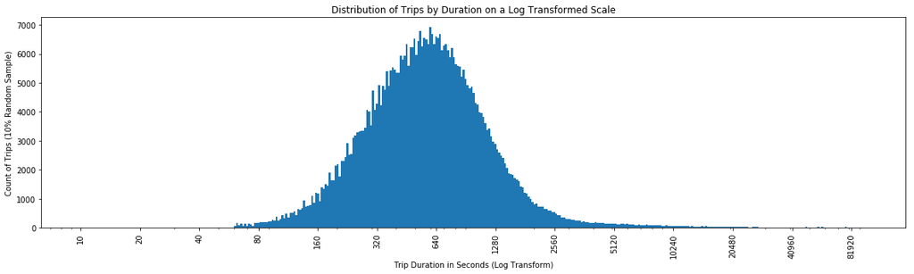

```python
plt.figure(figsize = [20, 5])

bins = 10 ** np.arange(1,5,.01)
#ticks = np.logspace(1,5,10, dtype='int')
ticks = [10, 20, 40, 80, 160, 320, 640, 1280, 2560, 5120, 10240, 20480, 40960, 81920]
labels = ['{}'.format(v) for v in ticks]

plt.hist(data = trip_df, x = "duration_sec", bins = bins);
plt.xscale('log');
plt.xticks(ticks, labels, rotation='vertical');
plt.xlabel("Trip Duration in Seconds (Log Transform)");
plt.ylabel("Count of Trips (10% Random Sample)");
plt.title("Distribution of Trips by Duration on a Log Transformed Scale");
```

## Heat Map Depicting Peak Rental Times

Below is a heat map depicting the peak trips lasting less than 50 minutes in duration by hour of the day. No huge surprise, however some useful data found in this chart. With the minimim count required to appear on the map set at 100, we see that nothing appears at all with start times between 2am and 5am. The number of trips heats up during the traditional commuting windows, with durations of the trips heating up in the 4-15 minute range. This data tells business owners a lot about the characteristics of their riders.

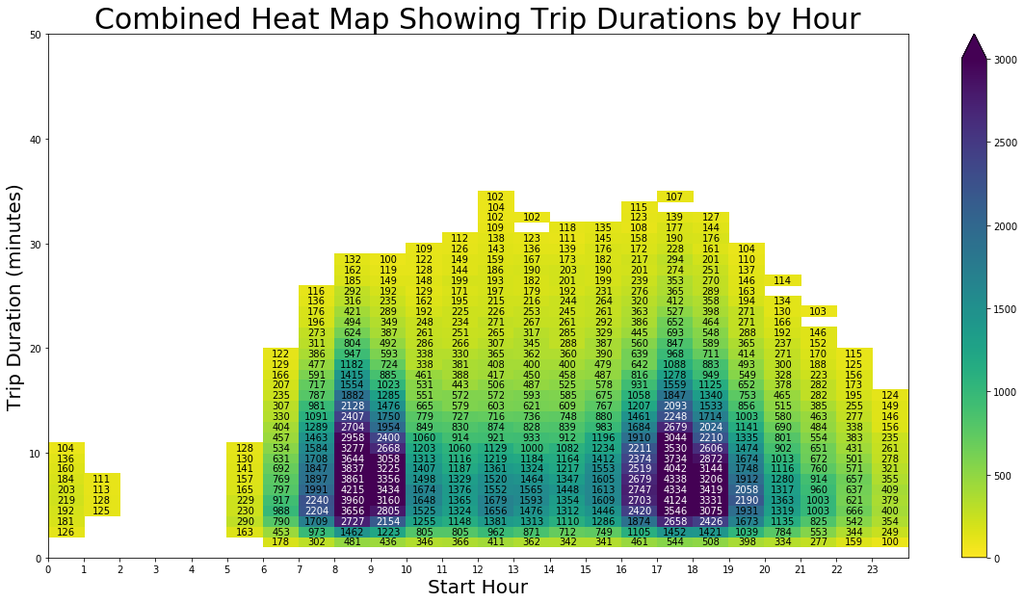

```python
fig = plt.figure(figsize = [20, 10])
heatplot(trip_df, title = 'Combined Heat Map Showing Trip Durations by Hour', ylim=50, vmax=3000, cmin=100, cmax=100000, colsplit=2000);
```

## Deeper Dive Into the Heat Map

Because the previous visualization is aggregated across the entire (10% sampled) data set, this visualization uses faceting,to break it down into separate heatmaps for each weekdayTwo things are made clear from this exercise. First, the patterns in the weekend days is broken out from weekdays giving some insight into how those days differ from weekdays. And second, it shows a tremendously high degree of consistency from weekday to weekday, almost down to the 10s of riders in each cell. This suggests that, not only is the usage consistent, but very likely the specific riders using the bikes during the peak periods are highly consistent. Not too surprising since most riders in the system are subscribers and the most likely riders to become subscribers are those who have consistent use and those riders likely commuters, the very consumer type the product is aiming to target.

(Note: Minimum counts are adjusted as compared to the previous visualization due to the lower overall counts in each chart. Otherwise, the x and y axis are held constant in order to provide consistent visuals as the charts are compared.)

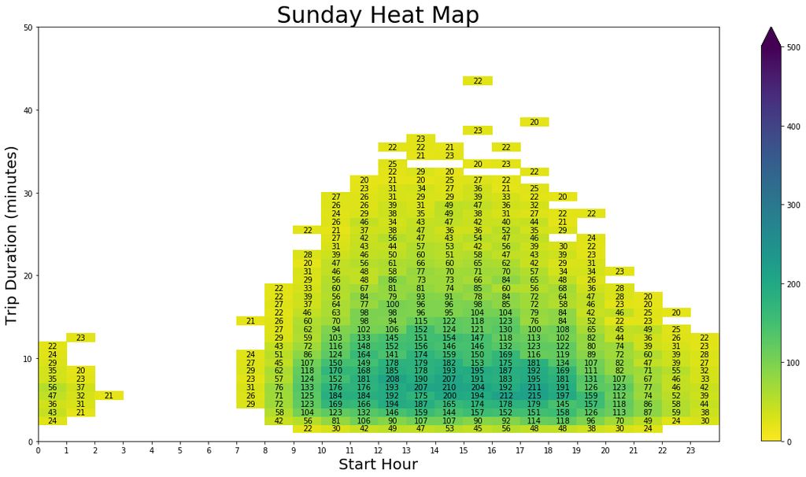

```python
fig = plt.figure(figsize = [20, 10])
heatplot(trip_df[trip_df.start_weekday == 'Sun'],title = 'Sunday Heat Map', colsplit=300);
```

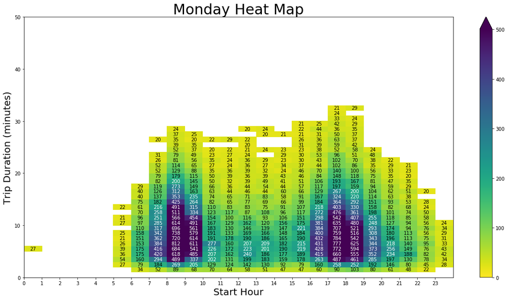

```python
fig = plt.figure(figsize = [20, 10])
heatplot(trip_df[trip_df.start_weekday == 'Mon'], title = 'Monday Heat Map');
```

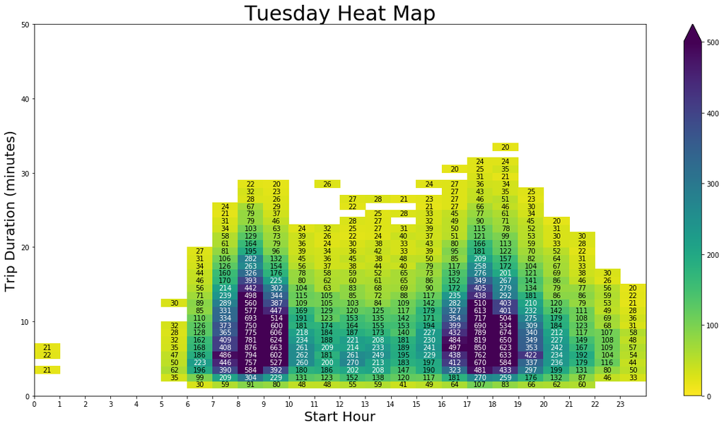

```python
fig = plt.figure(figsize = [20, 10])
heatplot(trip_df[trip_df.start_weekday == 'Tue'], title = 'Tuesday Heat Map');
```

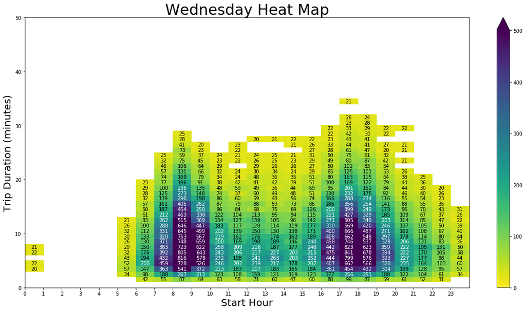

```python
fig = plt.figure(figsize = [20, 10])
heatplot(trip_df[trip_df.start_weekday == 'Wed'], title = 'Wednesday Heat Map');
```

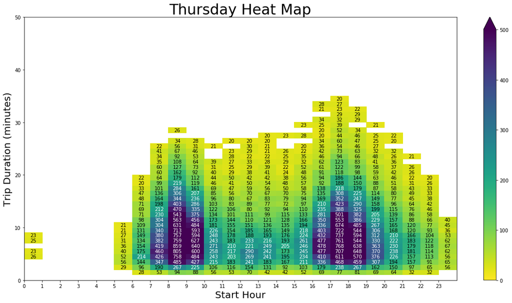

```python
fig = plt.figure(figsize = [20, 10])
heatplot(trip_df[trip_df.start_weekday == 'Thu'], title = 'Thursday Heat Map');
```

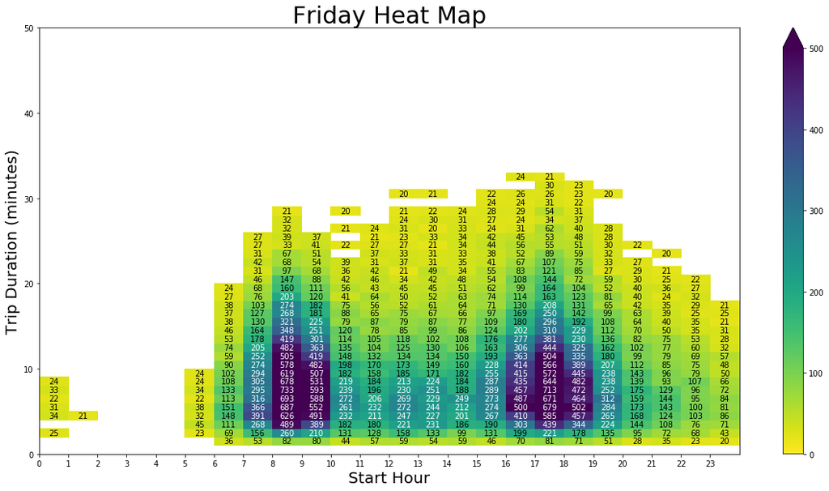

```python
fig = plt.figure(figsize = [20, 10])
heatplot(trip_df[trip_df.start_weekday == 'Fri'], title = 'Friday Heat Map');
```

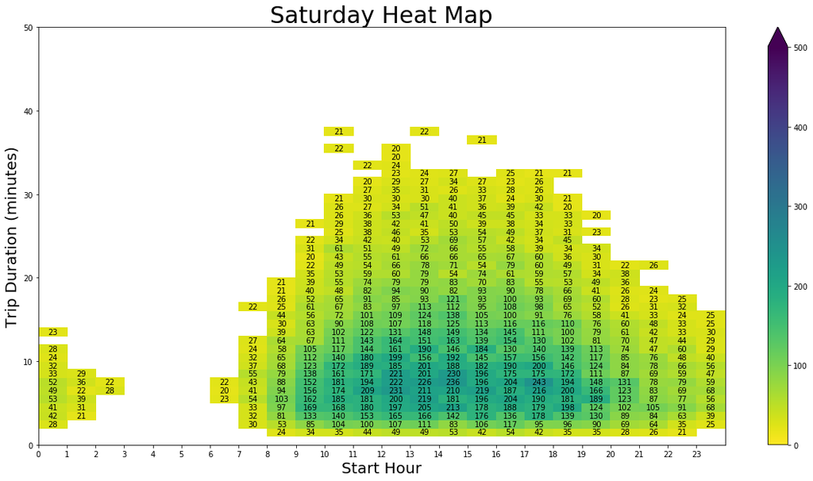

```python
fig = plt.figure(figsize = [20, 10])
heatplot(trip_df[trip_df.start_weekday == 'Sat'], title = 'Saturday Heat Map', colsplit=300);
```